# ¿Casa propia antes de los 40?

Explorar

# ¿Quién es dueño?

¿Quién es dueño?

Género del jefe del hogar

52.0%

de los hogares con **jefe hombre** son dueños

Quién encabeza el hogar

[figure not shown]

44.1%

de los hogares con **jefa mujer** son dueños

Brecha de **7.9 puntos**. En el modelo se mantiene: una jefa mujer tiene menores momios de ser dueña (OR 0.77).

¿Cómo viven?

Dueños = propia + la están pagando = **49.7%**. De los dueños, **27%** todavía la paga.

La edad pesa

35.0% son dueños

Cada figura = 5% de los hogares. Entre un grupo y otro hay **+20.9 puntos**.

# Locación

30%

69%

Locación

% de hogares jóvenes que son dueños de su vivienda

México

49.7%

Toca un estado del mapa para ver su resultado.

Por tamaño de localidad

Menos de 2,500 hab.

72.0%

2,500 a 15 mil

55.0%

15 mil a 100 mil

46.3%

100 mil o más

39.5%

23%18-29 años en ciudad grande

vs

76%30-39 años en pueblo

Cada estado tiene entre 499 y 1,280 hogares en la muestra: diferencias de pocos puntos entre estados no son concluyentes.

# La paradoja

La paradoja

Algunas comparaciones parecen contradictorias. Destapa cada carta para ver qué cambia al considerar el lugar.

¡Lotería!

La diferencia se entiende mejor al considerar la geografía: en localidades pequeñas predominan mecanismos de tenencia distintos a la compra de vivienda en el mercado urbano.

# Finanzas

Finanzas

Da clic en una columna del banco

[figure not shown]

Ingreso corriente del hogar

Equivalente mensual aproximado

No propietario

**$17,588**

Propietario

**$18,099**

Visto solo, casi no hay diferencia entre dueños e inquilinos.

**En el modelo:** al comparar parejo, más ingreso por persona sí se asocia con ser dueño (OR 2.59).

Ojo: el ingreso corriente de la ENIGH incluye un alquiler estimado para quien vive en casa propia.

Ingreso por trabajo

Equivalente mensual aproximado

No propietario

**$14,332**

Propietario

**$13,569**

Por su trabajo, los dueños ganan incluso un poco menos que los inquilinos.

La ligera ventaja de los dueños en ingreso total no viene del sueldo.

Gasto monetario

Equivalente mensual aproximado

No propietario

**$12,793**

Propietario

**$11,516**

Los inquilinos gastan más cada mes.

**En el modelo:** más gasto por persona se asocia con menores momios de ser dueño (OR 0.47).

Ojo: parte de ese gasto es la propia renta, así que la relación también va en sentido inverso.

Deudas y tarjeta de crédito

% de hogares que registran pagos

Pagos de deudas

No propietario

**5.0%**

Propietario

**6.8%**

Pagos con tarjeta

No propietario

**15.7%**

Propietario

**12.2%**

Pocos hogares jóvenes registran pagos de deudas; la tarjeta es más común entre inquilinos.

**En el modelo:** pagar deudas se asocia un poco con ser dueño (OR 1.22); la tarjeta no es significativa (OR 1.02, p = 0.77).

Son pagos registrados, no el saldo total de la deuda.

Montos: medianas de la muestra del EDA del equipo. La ENIGH reporta montos trimestrales; aquí se dividen entre 3 para obtener un equivalente mensual aproximado.

# Modelo

¿Qué permanece cuando controlamos por todo lo demás?

Regresión logística ponderada por el diseño de la ENIGH (svyglm). Cada punto compara los **momios** de ser dueño contra la categoría de referencia, con todo lo demás igual.

AumentaReduceNo significativo

0.707

AUC

Discriminación moderada (0.5 = azar, 1 = perfecta)

65.9%

Exactitud

Clasificados bien con umbral 0.5

74.7%

Sensibilidad

Dueños detectados como dueños

55.1%

Especificidad

No dueños detectados como no dueños

Logística vs. árbol de clasificación

LogísticaÁrbol

AUC

**0.71 / 0.68**

Exactitud

**0.66 / 0.65**

Sensibilidad

**0.75 / 0.73**

Especificidad

**0.55 / 0.56**

Variables más importantes (árbol)

Tamaño de localidad

Grupo de edad

Ingreso por persona

Estrato

Gasto por persona

Educación

Región

Prop. de ocupados

Integrantes

Prop. de menores

Métricas en la muestra de prueba (30%). La logística se eligió porque discrimina mejor que el árbol y sus resultados se pueden interpretar.

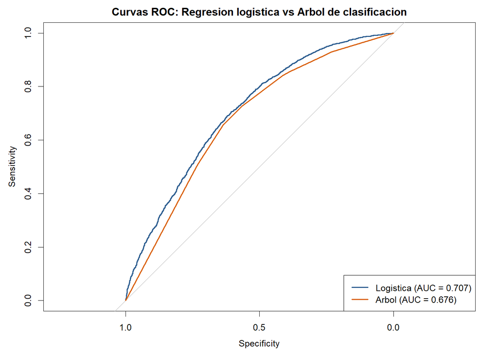

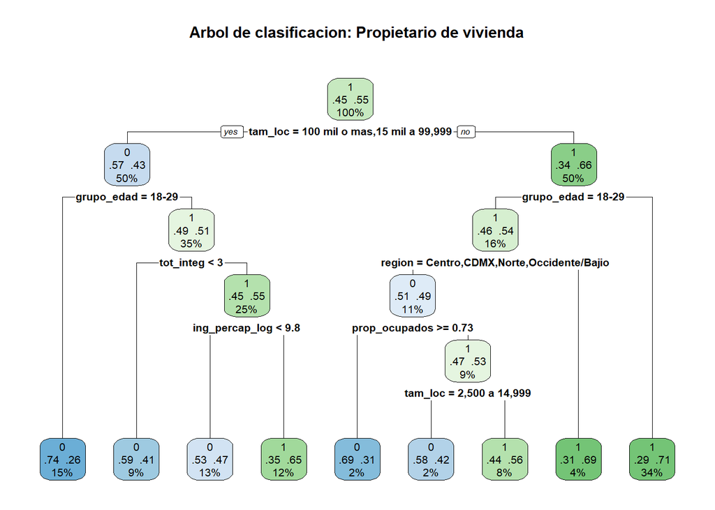

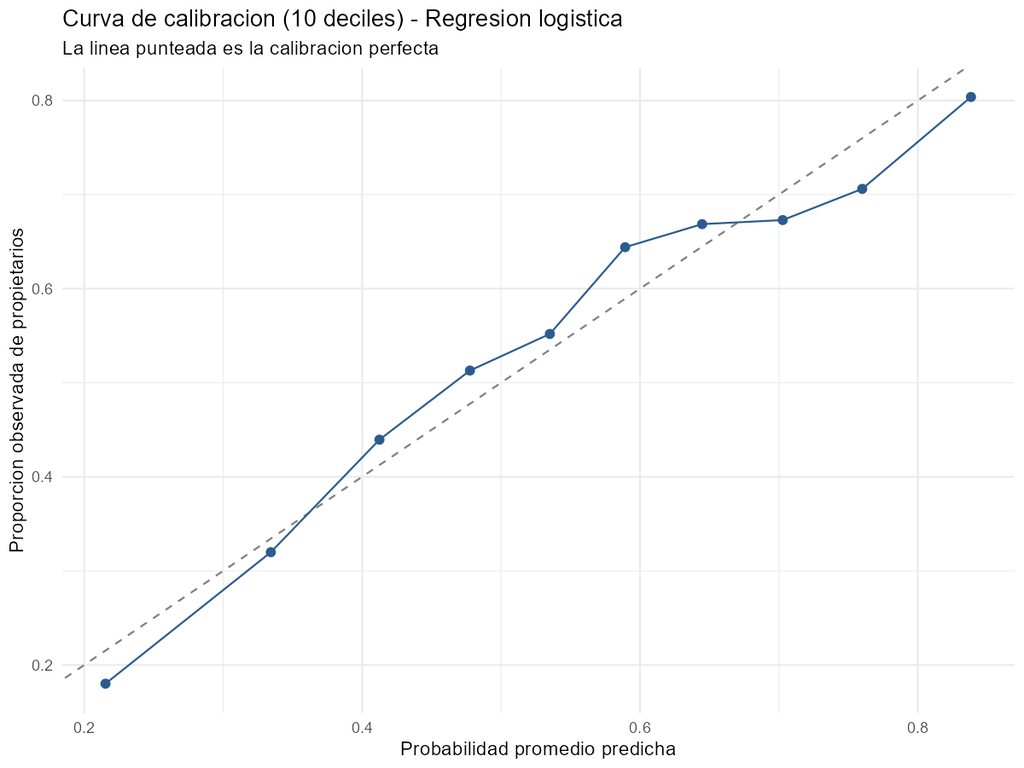

Desempeño de los modelos

| Modelo | Accuracy | Sensibilidad | Especificidad | Precisión | AUC |
| --- | --- | --- | --- | --- | --- |
| Regresion logistica | 0.659 | 0.747 | 0.551 | 0.671 | 0.707 |
| Arbol de clasificacion (CART) | 0.654 | 0.729 | 0.563 | 0.671 | 0.676 |

Resultados de la regresión logística ponderada

Los odds ratios provienen del modelo ponderado por el diseño muestral de la ENIGH.

| Variable | Odds ratio | IC 95% inferior | IC 95% superior | p-valor | Significativa |
| --- | --- | --- | --- | --- | --- |
| Localidad < 2,500 hab. (vs. 100 mil+) | 3.48 | 3.04 | 3.99 | < 0.001 | Sí |
| Edad 30-39 (vs. 18-29) | 2.49 | 2.25 | 2.75 | < 0.001 | Sí |
| Ingreso por persona (log) | 2.59 | 2.32 | 2.89 | < 0.001 | Sí |
| Gasto por persona (log) | 0.47 | 0.42 | 0.53 | < 0.001 | Sí |
| Proporción de ocupados | 0.46 | 0.36 | 0.57 | < 0.001 | Sí |
| Estrato 4 (vs. 1) | 0.46 | 0.37 | 0.58 | < 0.001 | Sí |
| Estrato 2 (vs. 1) | 0.60 | 0.51 | 0.70 | < 0.001 | Sí |
| Estrato 3 (vs. 1) | 0.52 | 0.43 | 0.63 | < 0.001 | Sí |
| (Intercept) | 0.04 | 0.01 | 0.10 | < 0.001 | Sí |
| Localidad 2,500-15 mil (vs. 100 mil+) | 1.75 | 1.47 | 2.09 | < 0.001 | Sí |
| Educación superior (vs. básica) | 1.69 | 1.43 | 1.99 | < 0.001 | Sí |
| Jefa mujer (vs. hombre) | 0.77 | 0.70 | 0.84 | < 0.001 | Sí |
| Sur/Sureste (vs. Centro) | 1.54 | 1.32 | 1.81 | < 0.001 | Sí |
| Integrantes del hogar | 1.14 | 1.09 | 1.20 | < 0.001 | Sí |
| Norte (vs. Centro) | 1.43 | 1.23 | 1.65 | < 0.001 | Sí |
| Media superior (vs. básica) | 1.39 | 1.20 | 1.60 | < 0.001 | Sí |
| Secundaria (vs. básica) | 1.31 | 1.15 | 1.50 | < 0.001 | Sí |
| Localidad 15-100 mil (vs. 100 mil+) | 1.28 | 1.11 | 1.48 | < 0.001 | Sí |
| Paga alguna deuda | 1.22 | 1.04 | 1.43 | 0.016 | Sí |
| CDMX (vs. Centro) | 0.84 | 0.63 | 1.12 | 0.234 | No |
| Occidente/Bajío (vs. Centro) | 1.05 | 0.90 | 1.24 | 0.510 | No |
| Paga con tarjeta | 1.02 | 0.89 | 1.17 | 0.768 | No |
| Proporción de menores | 0.99 | 0.76 | 1.30 | 0.947 | No |

Importancia de variables en el árbol

| Variable | Importancia |
| --- | --- |
| Tamaño de localidad | 415.89 |
| Grupo de edad | 328.39 |
| Ingreso por persona | 227.59 |
| Estrato | 189.43 |
| Gasto por persona | 188.97 |
| Educación | 146.35 |
| Región | 115.83 |
| Prop. de ocupados | 83.80 |
| Integrantes | 75.72 |
| Prop. de menores | 37.15 |

Las figuras corresponden a los diagnósticos generados en modelado.R; las tablas muestran los resultados guardados por el equipo.

**Odds ratio (OR):** compara los momios de ser propietario contra la categoría de referencia, manteniendo lo demás igual.

**OR mayor que 1:** aumenta los momios. Por ejemplo, OR 3.48 en localidades pequeñas: sus momios son unas 3.5 veces los de una ciudad grande.

**OR menor que 1:** los reduce. Por ejemplo, jefa mujer OR 0.77.

**IC 95%:** intervalo de confianza del 95% para el OR. Si contiene 1, el resultado no es estadísticamente significativo al 5%.

**p-valor:** evidencia estadística contra la hipótesis nula de ausencia de asociación.

**AUC:** mide la capacidad del modelo para discriminar entre propietarios y no propietarios.

**Exactitud:** proporción de observaciones clasificadas correctamente con el umbral utilizado.

**Sensibilidad:** proporción de propietarios identificados correctamente.

**Especificidad:** proporción de no propietarios identificados correctamente.

**Modelo ponderado:** regresión logística ajustada considerando UPM, estratos y factores de expansión de la ENIGH.

**Asociación, no causalidad:** el modelo describe relaciones estadísticas observadas; no demuestra qué provoca la propiedad de vivienda.

# Simulador

Simulador: ¿qué pasaría si…?

Describe tu hogar y mira cómo cambia la probabilidad al mover una sola característica.

Edad del jefe(a) del hogar: **25** años

Sexo

EscolaridadEstadoEl estado se traduce a la región utilizada por el modelo.

Tamaño de la localidad

Personas en el hogar: **2**Personas que trabajan: **1**Ingreso del hogar al mes: **$20,000**

¿Pagan alguna deuda?

0Promedio nacional: 50100

¿Qué pasaría si…?

Ilustrativo: se basa en asociaciones de la ENIGH 2024 entre hogares con jefe de 18 a 39 años. No predice tu caso ni es asesoría financiera.

# Conclusión

¿Qué nos llevamos del análisis?

La propiedad de vivienda entre hogares con jefatura de 18–39 años no se relaciona con una sola característica. Los resultados apuntan a una combinación de territorio, etapa de vida, condiciones económicas y características del hogar.

01

### El lugar marca la mayor brecha

72.0% de propiedad en localidades de menos de 2,500 habitantes frente a 39.5% en localidades de 100 mil o más.

OR 3.48localidad <2,500 vs. 100 mil+

02

### La edad marca una transición

La propiedad ponderada pasa de 35.0% entre 18–29 años a 55.9% entre 30–39.

+20.9 puntosOR de 30–39 vs. 18–29 = 2.49

03

### El dinero importa al analizarlo en conjunto

El ingreso per cápita se asocia positivamente con la propiedad, mientras que el gasto per cápita presenta una asociación negativa al controlar por el resto de características.

OR 2.59 / 0.47variables económicas transformadas y expresadas por persona

04

### Las comparaciones simples pueden cambiar

La educación superior muestra una menor proporción descriptiva de propiedad, pero se asocia con mayores momios después de controlar por ubicación y otras variables.

OR 1.69educación superior vs. básica o menos

05

### La brecha por sexo permanece

La tasa ponderada es 44.1% para hogares con jefa mujer y 52.0% para hogares con jefe hombre. La diferencia permanece en el modelo.

OR 0.77jefa mujer vs. hombre

06

### La logística ofrece interpretabilidad con desempeño moderado

**Conclusión principal.** La propiedad observada de vivienda entre hogares con jefatura de 18–39 años está asociada con una combinación de características demográficas, económicas y territoriales. El tamaño de localidad y la edad concentran las asociaciones más marcadas. El análisis es transversal y describe asociaciones; no demuestra causalidad ni mide directamente la asequibilidad de comprar una vivienda.

Métodos y datos

### Datos

**Fuente:** Encuesta Nacional de Ingresos y Gastos de los Hogares (ENIGH) 2024, INEGI.

**Población:** hogares cuyo jefe(a) tiene entre 18 y 39 años.

**Unidad:** el hogar (folioviv + foliohog). Muestra: **23,127** hogares, que representan **9.6 millones** con el factor de expansión.

**Variable objetivo:** propietario = 1 si la vivienda es propia o se está pagando; 0 si es rentada o prestada. Se excluyeron los casos intestados, en litigio u otra situación.

**Ponderación:** todos los porcentajes usan el factor de expansión; los modelos usan el diseño muestral (upm, estrato y factor).

### Modelos

**Modelo del equipo:** regresión logística ponderada (svyglm) con edad, sexo, educación, integrantes, menores, ocupados, ingreso y gasto per cápita, deuda, tarjeta, localidad, región y estrato. AUC en prueba = 0.707.

**Modelo del simulador:** la misma especificación sin estrato, gasto, tarjeta ni menores, para usar solo datos que una persona conoce. AUC dentro de muestra = 0.698.

### De dónde sale cada sección

| Sección | Del equipo | Calculado con la base |
| --- | --- | --- |
| ¿Quién es dueño? | % por sexo y edad (EDA.R) | Pastel por sexo y tipo de tenencia |
| Locación | % por tamaño de localidad (EDA.R) | % por estado y región; edad × localidad |
| La paradoja | % por estrato y localidad (EDA.R); OR del modelo | Educación, menores y dónde viven |
| Finanzas | Medianas de ingreso y gasto (EDA.R); OR del modelo | % con pagos de deuda y tarjeta |
| Modelo | Odds ratios, métricas, importancia y figuras (modelado.R) | — |
| Simulador | Definiciones y referencias de modelado.R | Modelo simplificado reestimado con svyglm |
| Conclusión | Síntesis de hallazgos del EDA y modelado.R | Conclusiones integradas del reporte |

### Limitaciones

- **Asociación, no causalidad:** los resultados describen con qué se relaciona ser dueño.
- **Un solo año:** no permite hablar de tendencias ni comparar generaciones en el tiempo.
- **Ingreso y gasto:** el ingreso corriente incluye un alquiler estimado para la vivienda propia y el gasto incluye la renta.
- **Deuda y tarjeta:** son pagos registrados, no saldos.
- **Estados:** cada uno tiene entre 499 y 1,280 hogares; diferencias pequeñas no son concluyentes.

### Créditos

Datos: INEGI, ENIGH 2024. Análisis: Equipo 8, Módulo 8.

Íconos: Font Awesome Free (CC BY 4.0). Mapa por entidad: repositorio angelnmara/geojson. Visualización: three.js y D3.

Código y base: [repositorio en GitHub](https://github.com/mvigil16/PROYECTO-8.-CONDICIONES-FINANCIERAS-POR-GENERACI-N-EN-M-XICO).

### Diccionario de variables

| Variable | Significado | Tipo |
| --- | --- | --- |
| `folioviv` | Identificador de la vivienda | Identificador |
| `foliohog` | Identificador del hogar dentro de la vivienda | Identificador |
| `propietario` | Variable binaria creada para identificar si la vivienda es propia | Binaria |
| `tenencia` | Tenencia de la vivienda | Categórica |
| `edad_jefe` | Edad del jefe del hogar | Numérica |
| `grupo_edad` | Grupo de edad del jefe del hogar | Categórica |
| `sexo_jefe` | Sexo del jefe del hogar | Categórica |
| `educa_jefe` | Nivel de escolaridad del jefe del hogar | Categórica |
| `tot_integ` | Total de integrantes del hogar | Numérica |
| `menores` | Número de integrantes menores | Numérica |
| `mayores` | Número de integrantes mayores | Numérica |
| `ocupados` | Número de integrantes ocupados | Numérica |
| `ing_cor` | Ingreso corriente del hogar | Numérica |
| `ingtrab` | Ingreso por trabajo | Numérica |
| `gasto_mon` | Gasto corriente monetario del hogar | Numérica |
| `deudas` | Pagos realizados por deudas | Numérica |
| `pago_tarje` | Pagos realizados mediante tarjeta de crédito | Numérica |
| `ubica_geo` | Código de ubicación geográfica | Identificador geográfico |
| `tam_loc` | Tamaño de localidad | Categórica |
| `factor` | Factor de expansión de la encuesta | Diseño muestral |
| `est_socio` | Estrato socioeconómico | Diseño muestral |
| `est_dis` | Estrato del diseño muestral | Diseño muestral |
| `upm` | Unidad primaria de muestreo | Diseño muestral |